# Hello World! By Julia Baratta and Sean Hall

The main objective of our project is to identify the variables that affect flight delays and create a predictive model that will display the probability that a given flight will be delayed based on set characteristics.

A major question we would like to answer is: does rain and snow affect the likelihood that your flight will be delayed? To tackle this variable, we chose to import and clean datasets from the National Center for Environmental Information that include data on daily precipitation in major US cities across the globe. We chose the ten cities with the largest airports to analyze. We hope to generalize the trend between weather and flight delays to every airport in the US with the assumption that they will behave reasonably similarly to our chosen cities.

Here's a link to where we got this data.

https://www.ncei.noaa.gov/access/search/data-search/daily-summaries?pageNum=1&startDate=2018-01-03T00:00:00&endDate=2018-01-03T23:59:59&dataTypes=AWND&dataTypes=PRCP&dataTypes=TAVG&bbox=38.030,-122.674,37.520,-122.164

**Discussion of our supplementary datasets:**

Large airports may be more equipped to handle storms and weather due to their robust infrastructure, leading to an inaccuracy within our model to predict delays in a variety of airport sizes. However, one could argue that the size of an airport has little effect on an individual plane’s ability to takeoff or land in unsafe conditions. Additionally, top-ten US airports will have the largest dataset of delayed and on-time flights, leading to a greater statistical significance. Finally, top-ten airports necessarily serve more people than any other grouping of ten airports. This means that a model accurate to these airports will have the largest probability of being correct and useful for any given flyer. For these reasons, we think that our supplementary datasets are useful in the goal of this project.

**Additional cleanup and trend analysis:**

Our goal is to create a model that considers many variables, not just weather. To attack this goal, we further tidied and analyzed our original dataset which contains details on every flight flown in the US. Below, you can see that we dropped unnecessary columns, and made the decision to delete rows with NaN values in them. This decision was informed by analysis of the relevant rows which we believe contain values that are missing at completely random. Additionally, they made up <2% of the dataset.

Below you will see an additional analysis of trends within our first dataset. The goal is to choose which variable to base our machine learning model on.

```python
import pandas as pd
import matplotlib.pyplot as plt
from matplotlib.ticker import MaxNLocator
import warnings
warnings.filterwarnings("ignore")
```

# Our second dataset consists of snow and rain fall in major US cities every day of the year from 2013 to 2023. Here, I have read in the file for New York City. Our goal is to use weather in the top 10 busiest airports in the US to generalize the affect that rain and snow have on airport delays in the US.

```python
#importing a csv file containing daily precipitation and snow in NYC for the last ten years
#rain and snow measured in tenths of a mm
weather = pd.read_csv("/Users/juliabaratta/Desktop/weather_data/USW00094789.csv")

#deletes select columns by creating a list of all columns
columns = weather.columns.tolist()

#deletes columns I want from that list
for i in ['STATION', 'DATE','NAME', 'PRCP','SNOW']:
    columns.remove(i)

#drops the list
weather_dropped = weather.drop(columns = columns)

#gets only the last ten years worth of days
rows = weather_dropped.tail(3967)
```

```python
#writes file with relevent columns and rows to a folder
file_path = "/Users/juliabaratta/Desktop/weather_data/newyork.csv"
rows.to_csv(file_path, index = False)
```

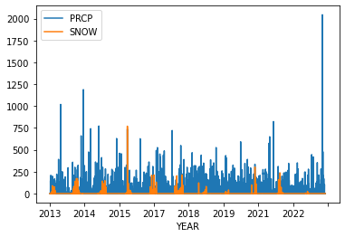

```python
#creates a column called YEAR based on a slice of the DATE column
rows['YEAR'] = rows["DATE"].str[:4]

#sets and index and plot
rows = rows.set_index('YEAR')
rows.plot()
```

Here we can see the yearly and seasonal variation in total precipitation. Orange spikes clearly indicate winters.

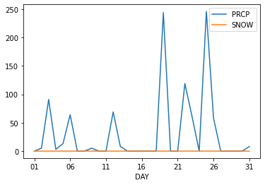

```python
#selects only Jan2023
w_Jan2023 = rows[3652:3683]

#creates a DAY column
w_Jan2023['DAY'] = w_Jan2023["DATE"].str[8:]
w_Jan2023.set_index("DAY", inplace = True)
w_Jan2023.plot()
```

Zoomed in, we can see the daily rain and snow in January of 2023

```python
#reads in airline data for Jan of 2023
a_Jan2023 = pd.read_csv("/Users/juliabaratta/Desktop/airline_data/Jan2023.csv")
```

```python
#selects only flights going to NYC
a_Jan2023NY_d = a_Jan2023[a_Jan2023['DEST_CITY_NAME'] == 'New York, NY']

#selects only flights leaving NYC
a_Jan2023NY_o = a_Jan2023[a_Jan2023['ORIGIN_CITY_NAME'] == 'New York, NY']
```

```python
#creates a groupby object for the sum of all delayed minutes on each day of January
d_by_dowJan2023_o = (a_Jan2023NY_o.groupby('DAY_OF_MONTH')['DEP_DELAY_NEW'].sum())
d_by_dowJan2023_d = (a_Jan2023NY_d.groupby('DAY_OF_MONTH')['DEP_DELAY_NEW'].sum())

#standardizes
d_by_dowJan2023_std_o = (
    (d_by_dowJan2023_o - d_by_dowJan2023_o.mean()) /
    d_by_dowJan2023_o.std())

d_by_dowJan2023_std_d = (
    (d_by_dowJan2023_d - d_by_dowJan2023_d.mean()) /
    d_by_dowJan2023_d.std())

w_Jan2023_std = (
    (w_Jan2023 - w_Jan2023.mean()) /
    w_Jan2023.std())

#converts to df
w_Jan2023_std = pd.DataFrame(w_Jan2023_std)
```

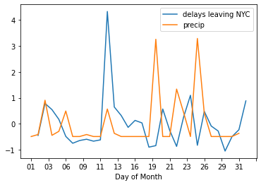

```python
#plots delays and precipitation
plt.plot(d_by_dowJan2023_std_o, label = 'delays leaving NYC')
plt.plot(w_Jan2023_std.index, w_Jan2023_std['PRCP'], label = 'precip')
plt.xlabel('Day of Month')
plt.legend()
plt.gca().xaxis.set_major_locator(MaxNLocator(nbins=15))
```

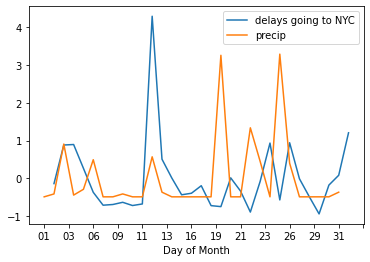

```python
plt.plot(d_by_dowJan2023_std_d, label = 'delays going to NYC')
plt.plot(w_Jan2023_std.index, w_Jan2023_std['PRCP'], label = 'precip')
plt.xlabel('Day of Month')
plt.legend()
plt.gca().xaxis.set_major_locator(MaxNLocator(nbins=15))
```

We see the same trends for delays going into NYC.

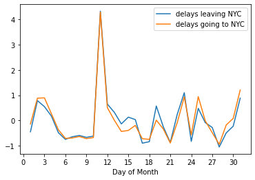

```python
plt.plot(d_by_dowJan2023_std_o, label = 'delays leaving NYC ')
plt.plot(d_by_dowJan2023_std_d, label = 'delays going to NYC')
plt.xlabel('Day of Month')
plt.legend()
plt.gca().xaxis.set_major_locator(MaxNLocator(nbins=13))
```

In fact, delays leaving NYC and delays going into NYC are almost perfectly correlated. Clearly, delays are unaffected by whether the airport is incoming or outgoing.

Below are some additional relationships that can be derrived from the weather dataset

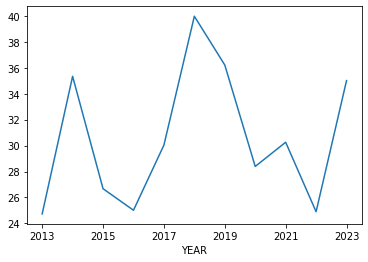

```python
#averages yearly precipitation in NYC
yearly_precip = rows.groupby("YEAR")["PRCP"].mean()
yearly_precip.plot()
```

2016 & 2022 did not get a lot of rain

Here's a link to a wiki page that talks about the 2016 drought in NY

https://en.wikipedia.org/wiki/2016_New_York_drought

Here's a link to a drought declaration in the summer months of 2022

https://www.dec.ny.gov/press/126319.html#:~:text=In%20August%202022%2C%20Governor%20Kathy,flows%20and%20low%20groundwater%20levels.

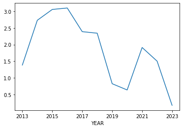

```python
#averages yearly snow in NYC
yearly_precip = rows.groupby("YEAR")["SNOW"].mean()
yearly_precip.plot()
```

We can see here that snow levels have been decreasing on average. This is possibly a small-scale reflection of atmospheric warming.

Here's a notebook that imports, cleans, and combines all of our airline data into one large dataset. We will use this file when we have completely debugged and finalized our code.

```python
end_year = 2023

selected_columns = ['Year', 'Month', 'DayofMonth', 'DayOfWeek', 'DOT_ID_Reporting_Airline',
      'OriginAirportID',
     'OriginCityMarketID', 'OriginCityName',
       'OriginStateName',
       'DestAirportID', 'DestCityMarketID',
       'DestCityName', 'DestStateName',
    'CRSDepTime', 'DepTime', 'DepDelayMinutes',
     'TaxiOut',
      'TaxiIn', 'CRSArrTime', 'ArrTime',
       'ArrDelayMinutes', 'CancellationCode', 'CRSElapsedTime',
       'ActualElapsedTime', 'AirTime', 'Distance',
       'CarrierDelay', 'WeatherDelay', 'NASDelay', 'SecurityDelay',
       'LateAircraftDelay', ]

start_time = time.time()
# Define the range of years you want to read data for
start_year = 2013
end_year = 2023  # Adjust the end year as needed

# Initialize an empty list to store DataFrames
data_frames = []

# Loop through the years and months and read data into DataFrames
for year in range(start_year, end_year + 1):
    max_month = 12 if year != 2023 else 8
    for month in range(1, max_month + 1):
        file_path = f"airline_data/{year}/On_Time_Reporting_Carrier_On_Time_Performance_1987_present_{year}_{month}/On_Time_Reporting_Carrier_On_Time_Performance_(1987_present)_{year}_{month}.csv"
        try:
            df = pd.read_csv(file_path, usecols=selected_columns)
            data_frames.append(df)
        except FileNotFoundError:
            print(f"File not found for {year}-{month}")

# Concatenate all the DataFrames into one
final_df = pd.concat(data_frames, ignore_index=True)

# Now final_df contains data from all specified years and months with the selected columns
end_time = time.time()
execution_time = end_time - start_time
print(f"Execution time: {execution_time} seconds")

with open('airline_data/FullAirline.csv','w'):
    pass

final_df.to_csv('FullAirline.csv',index=False)

print(final_df.shape)
```

```python
import pandas as pd
import numpy as np
import seaborn as sns
import matplotlib.pyplot as plt

df = pd.read_csv('/Users/juliabaratta/Desktop/airline_data/sample1000df.csv')

#Changing CancellationCodes
df["CancellationReason"] = df["CancellationCode"].replace({'A':"Carrier",'B':"Weather",'C':"National Air System",'D':"Security",np.nan:'No Delay'})
df.drop(columns=['CancellationCode'],inplace=True)

#Changing Airline Name Column
DOT_ID_Airline_df = pd.read_csv('/Users/juliabaratta/Desktop/airline_data/L_AIRLINE_ID.csv')
ID_map_dict = dict(zip(DOT_ID_Airline_df['Code'], DOT_ID_Airline_df['Description'].str.split(':').str[0]))
df['Airline'] = df['DOT_ID_Reporting_Airline'].map(ID_map_dict)
df.drop(columns=['DOT_ID_Reporting_Airline'],inplace=True)

#Cleaning data (Some airlines did NaN on delays when they didn't exist. These are equivalent to a 0 time delay.)
#Also, there are 2% of rows that have NaN values. I looked for a correlation and none existed. This should not affect our data. I will drop these rows.
fill_columns = ['CarrierDelay','WeatherDelay','NASDelay','SecurityDelay','LateAircraftDelay']
df[fill_columns] = df[fill_columns].fillna(0)
df.dropna(inplace=True)

#Changing DayOfWeek column
DayOfWeek_mapping = {1:'Mon',2:'Tues',3:'Wed',4:'Thurs',5:'Fri',6:'Sat',7:'Sun'}
df['DayOfWeek'] = df['DayOfWeek'].map(DayOfWeek_mapping)

#Fixing OriginAirportID
ForeignKey = pd.read_csv('/Users/juliabaratta/Desktop/airline_data/L_AIRPORT_ID.csv')
ForeignKeyDict = dict(zip(ForeignKey['Code'], ForeignKey['Description']))
df['OriginAirport'] = df['OriginAirportID'].map(ForeignKeyDict)
df.drop(columns=['OriginAirportID'],inplace=True)

#Fixing OriginCityMarketID, changing name to OriginArea.
ForeignKey = pd.read_csv('/Users/juliabaratta/Desktop/airline_data/L_CITY_MARKET_ID.csv')
ForeignKeyDict = dict(zip(ForeignKey['Code'], ForeignKey['Description']))
df['OriginArea'] = df['OriginCityMarketID'].map(ForeignKeyDict)
df.drop(columns=['OriginCityMarketID'],inplace=True)

#Fixing Months
ForeignKey = pd.read_csv('/Users/juliabaratta/Desktop/airline_data/L_MONTHS.csv')
ForeignKeyDict = dict(zip(ForeignKey['Code'], ForeignKey['Description']))
df['Month'] = df['Month'].map(ForeignKeyDict)

#Fixing DestAirportID
ForeignKey = pd.read_csv('/Users/juliabaratta/Desktop/airline_data/L_AIRPORT_ID.csv')
ForeignKeyDict = dict(zip(ForeignKey['Code'], ForeignKey['Description']))
df['DestAirport'] = df['DestAirportID'].map(ForeignKeyDict)
df.drop(columns=['DestAirportID'],inplace=True)

#Fixing DestCityMarketID
ForeignKey = pd.read_csv('/Users/juliabaratta/Desktop/airline_data/L_CITY_MARKET_ID.csv')
ForeignKeyDict = dict(zip(ForeignKey['Code'], ForeignKey['Description']))
df['DestArea'] = df['DestCityMarketID'].map(ForeignKeyDict)
df.drop(columns=['DestCityMarketID'],inplace=True)


#FUN FACTS!!


#Airline with the Most Delays:
most_delayed_airline = df.groupby('Airline')['DepDelayMinutes'].mean().idxmax()
print(f"The airline with the most delays is {most_delayed_airline}.")

#Month with the Most Delays:
month_most_delays = df.groupby('Month')['DepDelayMinutes'].mean().idxmax()
print(f"The month with the most delays is {month_most_delays}.")

#Year with the Most Delays:
year_most_delays = df.groupby('Year')['DepDelayMinutes'].mean().idxmax()
print(f"The year with the most delays is {year_most_delays}.")

#Airport with the Longest Average Taxi Out Time:
airport_longest_taxi_out = df.groupby('OriginAirport')['TaxiOut'].mean().idxmax()
print(f"The airport with the longest average taxi out time is {airport_longest_taxi_out}.")

#Average Arrival Delay by City:
avg_arrival_delay_by_city = df.groupby('DestCityName')['ArrDelayMinutes'].mean().idxmax()
print(f"The city with the highest average arrival delay is {avg_arrival_delay_by_city}.")

#Busiest Airport (Most Flights):
busiest_airport = df['OriginAirport'].value_counts().idxmax()
print(f"The busiest airport (with the most flights) is {busiest_airport}.")

#Month with the Highest Average Airtime:
month_highest_airtime = df.groupby('Month')['AirTime'].mean().idxmax()
print(f"The month with the highest average airtime is {month_highest_airtime}.")

#Most Common Delay Type:
most_common_delay_type = df[['CarrierDelay', 'WeatherDelay', 'NASDelay', 'SecurityDelay', 'LateAircraftDelay']].idxmax(axis=1).mode().values[0]
print(f"The most common delay type is {most_common_delay_type}.")

#Day of the Week with the Fewest Delays:
day_fewest_delays = df.groupby('DayOfWeek')['DepDelayMinutes'].mean().idxmin()
print(f"The day of the week with the fewest delays is {day_fewest_delays}.")
```

[output not shown]

```python
####Below is trying to find correlations

target_columns = ['ArrDelayMinutes', 'DepDelayMinutes']

# Filter numeric columns only
numeric_columns = df.select_dtypes(include=['number']).columns

# Compute correlation matrix for numeric columns
correlation_matrix = df[numeric_columns].corr()
# Extract correlations with the target columns
correlations_with_target = correlation_matrix[target_columns]

# Display columns with the highest correlation for each target
for target_column in target_columns:
    correlated_columns = correlations_with_target[target_column].sort_values(ascending=False)
    print(f"\nColumns most correlated with '{target_column}':")
    print(correlated_columns)
```

```
Columns most correlated with 'ArrDelayMinutes':
ArrDelayMinutes       1.000000
DepDelayMinutes       0.974393
CarrierDelay          0.645761
LateAircraftDelay     0.630064
NASDelay              0.407067
WeatherDelay          0.321167
TaxiOut               0.172174
DepTime               0.121606
TaxiIn                0.091493
CRSDepTime            0.081724
CRSArrTime            0.073066
ActualElapsedTime     0.048080
SecurityDelay         0.030670
ArrTime               0.025069
AirTime               0.019771
CRSElapsedTime        0.012175
Year                  0.008453
Distance              0.008049
DayofMonth            0.001968
DestAirportSeqID      0.001819
OriginAirportSeqID   -0.003439
Cancelled                  NaN
Diverted                   NaN
Name: ArrDelayMinutes, dtype: float64

Columns most correlated with 'DepDelayMinutes':
DepDelayMinutes       1.000000
ArrDelayMinutes       0.974393
CarrierDelay          0.653003
LateAircraftDelay     0.640672
WeatherDelay          0.314429
NASDelay              0.313769
DepTime               0.134092
CRSDepTime            0.093539
CRSArrTime            0.080064
TaxiOut               0.054204
SecurityDelay         0.030607
ArrTime               0.027783
TaxiIn                0.022721
ActualElapsedTime     0.021913
CRSElapsedTime        0.017979
AirTime               0.013688
Distance              0.013388
Year                  0.010644
DestAirportSeqID      0.002545
DayofMonth            0.002377
OriginAirportSeqID   -0.003697
Cancelled                  NaN
Diverted                   NaN
Name: DepDelayMinutes, dtype: float64
```

To summarize, our project's goal is to try and predict the likelihood that a flight will be delayed based on information about the flight. A flight delay is incredibly convoluted and based on several factors, one of which is random chance. Our goal is to combine various weakly correlated factors to make the best model possible given our data. Some examples of variables we will test and potentially include are: Departure Time, Air Time, Year, Distance, Day of Month, and Airport being flown into and out of, and maybe even holidays/high traffic times. This data will be combined with rain and snowfall to form a predictive model. Two examples of models we might use are decision tree and k-nearest neighbor. When creating and testing our models, we will standardize columns to portray the data more accurately. For example, to test the effect of airline carrier on delay, we will standardize the data based on airline capacity. This eliminates the possibility of predicting that if you fly Southwest, you’re more likely to have delays just because that is the largest airline carrier in the world. This decision also allows us to isolate and explain valid trends between airline carriers such as flight delay policies, qualification of staff, importance of safety, etc.